# Visualizing Data

[Handbook Homepage](https://politicalscience.github.io)

## Table of Contents

- Histograms
- Boxplots
- Scatterplots (With Best Fit Line)
- Pairs and Correlations: pairs(), cor()

Remember to load tidyverse

```r
library(tidyverse)
```

Let us also load the dataset we will use for these examples:

```r
df <- read_csv("const-econ-vars.csv")
```

Table of Contents

## Histograms

We can create histograms with the **ggplot()** and **geom_histogram()** function. In the example below:

- **df** is the name of the dataframe, where the variable you want to plot is stored in. You can alter this to whatever your data frame is called.
- **WageMedianConst** is the variable we are plotting this histogram for. You can alter this to whatever variable you want to plot.

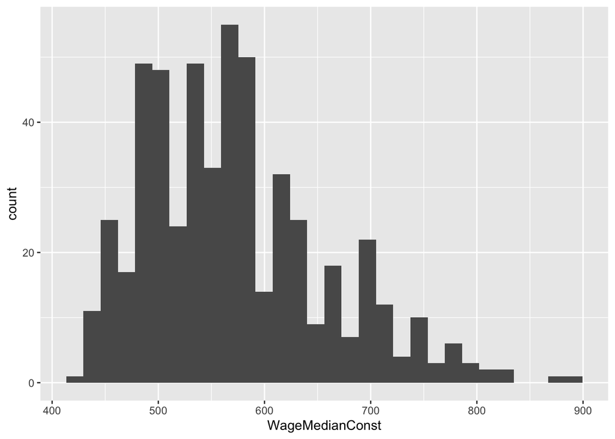

```r
df %>%
  ggplot(aes(x=WageMedianConst)) +
  geom_histogram()
```

We can customise this plot further with arguments within the **geom_histogram()** function.

In the example below:

- The **binwidth** argument is how wide we want every rectangle in the histogram to be. Larger numbers make the rectangles wider.
- The **color** argument is the color of the border of the rectangles. Remember to put the color in quotations.
- The **fill** argument is the color of the internal parts of the rectangles. Remember to put the color in quotations.
- You don’t have to include all 3 arguments. You can include 0, 1, 2, or 3. Remember to separate these by commas.

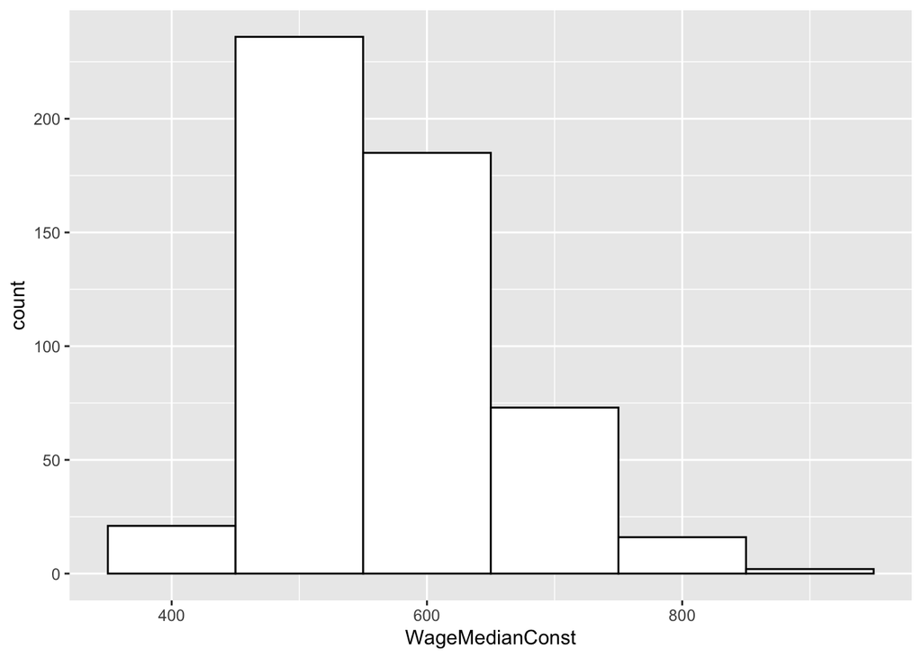

```r
df %>%
  ggplot(aes(x=WageMedianConst)) +
  geom_histogram(binwidth = 100, color = "black", fill = "white")
```

We can further complicate this by adding a mean line with **geom_vline()** , and a density function with **geom_density()**.

In the example below:

- The **alpha** argument in **geom_density()** defines the transparency of the fill in the density plot.
- **WageMedianConst** is the variable being plotting in this example. You should change this to the name of the variable you are plotting. Make sure to change both the variable name in the **ggplot()** function and the **geom_vline()** function.

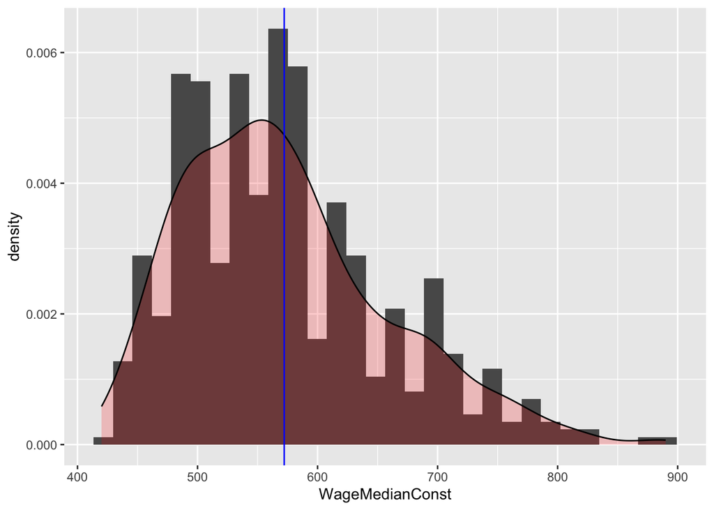

```r
df %>%
  ggplot(aes(x=WageMedianConst)) +
  geom_histogram(aes(y=..density..)) +
  geom_density(alpha = 0.2, fill = "red") +
  geom_vline(aes(xintercept = mean(WageMedianConst)), color = "blue")
```

Table of Contents

## Boxplots

We can create Boxplots with the **ggplot()** and **geom_boxplot()** functions. In the example below:

- **df** is the name of the dataframe, where the variable you want to plot is stored in. You can alter this to whatever your data frame is called.
- **WageMedianConst** is the variable we are plotting this histogram for. You can alter this to whatever variable you want to plot.

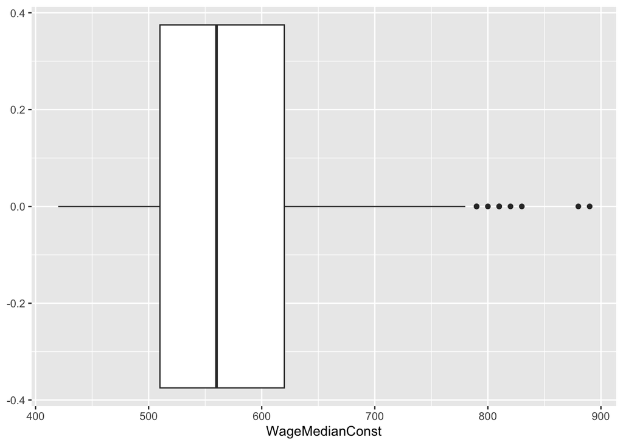

```r
df %>%
  ggplot(aes(x = WageMedianConst)) +
  geom_boxplot()
```

We can compare a boxplot between categories by altering the **aes()** as follows:

- **x =** the variable with categories
- **y =** the variable we want to make boxplots of.

We can also rotate the boxplot with the command **coord_flip()**

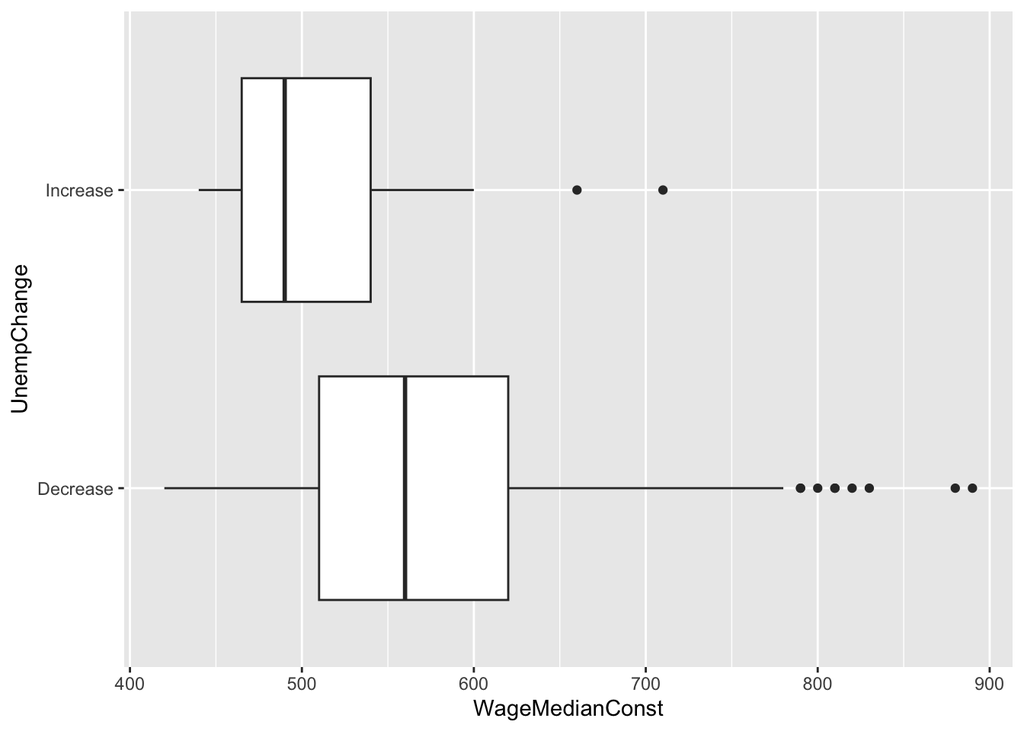

```r
df %>%
  ggplot(aes(x = UnempChange, y = WageMedianConst)) +
  geom_boxplot() +
  coord_flip()
```

Table of Contents

## Scatterplots (With Best Fit Line)

We can create scatterplots between two variables with the **ggplot()**, **geom_point()**, and **geom_smooth()** functions.

In the example below:

- **df** is the name of the dataframe, where the variable you want to plot is stored in. You can alter this to whatever your data frame is called.
- **WageMedianConst** is the variable we are plotting on the x axis. You can alter this to whatever you want to plot on the x axis.
- **deprivation_index_score** is the variable on the y axis. You can alter this to whatever you want to plot on the y axis.
- The **geom_smooth()** function plots the best fit line. You can change the color to what you want it to be.

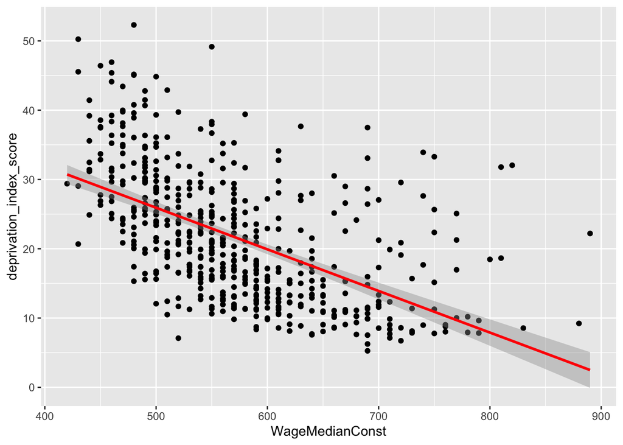

```r
df %>%
  ggplot(aes(x = WageMedianConst, y = deprivation_index_score)) +
  geom_point() +
  geom_smooth(method = "lm", color = "red")
```

We can also get a more “curvy” best fit line by removing the **method = “lm”** section.

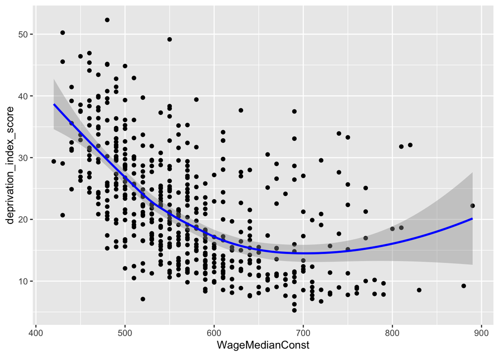

```r
df %>%
  ggplot(aes(x = WageMedianConst, y = deprivation_index_score)) +
  geom_point() +
  geom_smooth(, color = "blue")
```

Table of Contents

## Pairs and Correlations: pairs(), cor()

The functions of **paris()** and **cor()** allow us to see the correlations between all the variables in the dataset.

- IMPORTANT NOTE: pairs() and cor() require us to only use numerical data. Textual data will cause the functions to fail.

In the figure below:

- We first filter out the columns that are not numerical in our original **df** dataframe: I did this with the indexing method, but you can also use the **select()** function to deselect these columns. See the managing data section on how to do this.
- Then, we use the pairs() function. See the correlation plot matrices that are created.

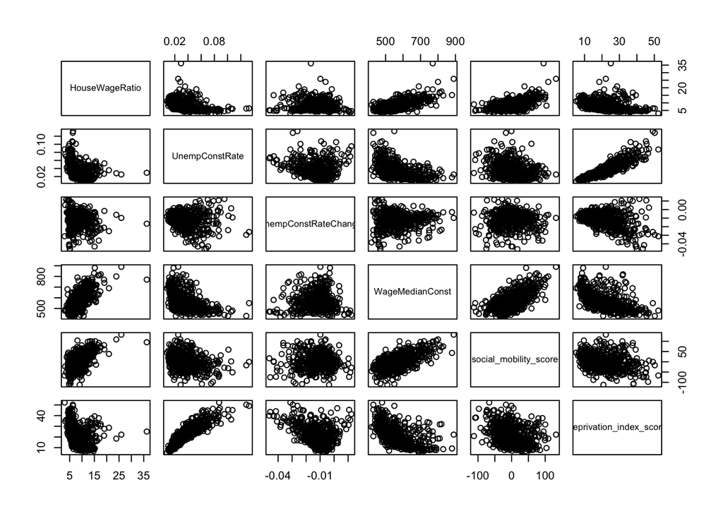

```r
pairs(df[,-c(1, 2, 9)])
```

If we want a more numerical description of the relationships between the variables, we can use the **cor()** function, which outputs Pearson Correlation Coefficients.

```r
cor(df[,-c(1, 2, 9)])
```

```
##                         HouseWageRatio UnempConstRate UnempConstRateChange
## HouseWageRatio              1.00000000     -0.4046661          -0.04315087
## UnempConstRate             -0.40466605      1.0000000          -0.17464744
## UnempConstRateChange       -0.04315087     -0.1746474           1.00000000
## WageMedianConst             0.68085593     -0.5213966           0.04474139
## social_mobility_score       0.56334450     -0.2587058           0.03042990
## deprivation_index_score    -0.33117140      0.9033701          -0.39032537
##                         WageMedianConst social_mobility_score
## HouseWageRatio               0.68085593             0.5633445
## UnempConstRate              -0.52139659            -0.2587058
## UnempConstRateChange         0.04474139             0.0304299
## WageMedianConst              1.00000000             0.6615778
## social_mobility_score        0.66157778             1.0000000
## deprivation_index_score     -0.54623274            -0.3049172
##                         deprivation_index_score
## HouseWageRatio                       -0.3311714
## UnempConstRate                        0.9033701
## UnempConstRateChange                 -0.3903254
## WageMedianConst                      -0.5462327
## social_mobility_score                -0.3049172
## deprivation_index_score               1.0000000
```

Table of Contents

[Handbook Homepage](https://politicalscience.github.io)